# 作業2

請依狀況更改上面的name,id及group（分別代表組員姓名，學號及組號），但請「勿」更改下面姓名、學號、組號三行的設定。

姓名：彭楷雯  
學號：710661111  
組號：6

```r
library(dplyr)
library(magrittr)
library(AER)
```

# 勞動市場

執行以下程式引入勞動市場資料labordata，資料說明請見連結[Cornwell and Rupert Returns to Schooling Data, 595 Individuals, 7 Years.](http://people.stern.nyu.edu/wgreene/Econometrics/PanelDataSets.htm)

```r
library(readr)
labordata <- read_csv("http://people.stern.nyu.edu/wgreene/Econometrics/cornwell&rupert.csv")
```

## 勞動供給

### (1)

將labordata只留下第7年的資料

```r
labordata %<>% filter(YEAR=="7")
labordata
```

| EXP | WKS | OCC | IND | SOUTH | SMSA | MS | FEM | UNION | ED | BLK | LWAGE | EXPSQ | YEAR | LOGWKS | ID | EXPB | WKSB | OCCB | INDB | SOUTHB | SMSAB | UNIONB | EXPSQB |
| --- | --- | --- | --- | --- | --- | --- | --- | --- | --- | --- | --- | --- | --- | --- | --- | --- | --- | --- | --- | --- | --- | --- | --- |
| 9 | 32 | 0 | 1 | 1 | 0 | 1 | 0 | 0 | 9 | 0 | 6.24417 | 81 | 7 | 3.465736 | 1 | 6 | 37.57143 | 0.0000000 | 0.4285714 | 1.0000000 | 0.0000000 | 0.0000000 | 40 |
| 36 | 30 | 1 | 1 | 0 | 0 | 1 | 0 | 0 | 11 | 0 | 6.81564 | 1296 | 7 | 3.401197 | 2 | 33 | 31.57143 | 1.0000000 | 0.7142857 | 0.0000000 | 0.0000000 | 0.1428571 | 1093 |
| 12 | 46 | 1 | 1 | 0 | 0 | 0 | 0 | 1 | 12 | 0 | 6.86066 | 144 | 7 | 3.828641 | 3 | 9 | 50.42857 | 1.0000000 | 1.0000000 | 0.0000000 | 0.0000000 | 1.0000000 | 85 |
| 37 | 46 | 1 | 0 | 0 | 1 | 0 | 1 | 0 | 10 | 1 | 6.62141 | 1369 | 7 | 3.828641 | 4 | 34 | 47.85714 | 1.0000000 | 0.0000000 | 0.0000000 | 1.0000000 | 0.0000000 | 1160 |
| 16 | 49 | 0 | 0 | 0 | 0 | 1 | 0 | 0 | 16 | 0 | 7.29574 | 256 | 7 | 3.891820 | 5 | 13 | 47.00000 | 0.5714286 | 0.0000000 | 0.0000000 | 0.1428571 | 0.4285714 | 173 |
| 32 | 47 | 1 | 1 | 0 | 1 | 1 | 0 | 0 | 12 | 0 | 7.33889 | 1024 | 7 | 3.850148 | 6 | 29 | 45.85714 | 1.0000000 | 1.0000000 | 0.0000000 | 1.0000000 | 0.0000000 | 845 |
| 21 | 48 | 1 | 0 | 0 | 0 | 1 | 0 | 1 | 12 | 0 | 6.52209 | 441 | 7 | 3.871201 | 7 | 18 | 47.28571 | 1.0000000 | 0.0000000 | 0.0000000 | 0.0000000 | 1.0000000 | 328 |
| 29 | 51 | 1 | 1 | 0 | 1 | 1 | 0 | 1 | 10 | 0 | 6.89163 | 841 | 7 | 3.931826 | 8 | 26 | 49.57143 | 1.0000000 | 1.0000000 | 0.5714286 | 0.4285714 | 1.0000000 | 680 |
| 9 | 48 | 0 | 0 | 1 | 1 | 1 | 0 | 0 | 16 | 0 | 7.20786 | 81 | 7 | 3.871201 | 9 | 6 | 48.00000 | 0.0000000 | 0.0000000 | 1.0000000 | 1.0000000 | 0.0000000 | 40 |
| 9 | 40 | 0 | 0 | 1 | 1 | 1 | 0 | 0 | 16 | 0 | 6.73934 | 81 | 7 | 3.688880 | 10 | 6 | 43.28571 | 0.0000000 | 0.0000000 | 1.0000000 | 1.0000000 | 0.0000000 | 40 |

[output cut: 585 more lines]

### (2)

我們想要估計薪資對工時的影響（即勞動供給），考慮如下的勞動供給函數
$$wks_{i}=\beta_0+\beta_1 lwage_{i}+\epsilon_i$$

請使用plot()畫出橫軸為每週工時（WKS）與縱軸為取對數後薪資（LWAGE, 後往直接稱呼「薪資」）的離散圖。

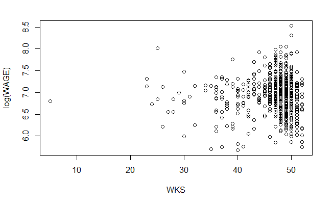

```r
ols1 <- lm(WKS~LWAGE,data=labordata)
plot(labordata$WKS, labordata$LWAGE, xlab="WKS", ylab="log(WAGE)")
```

### (3)

我們擔心「勞工屬於工會」這個變數(union, 為1若屬於工會, 反之為0)遺漏的話會造成勞動供給的工資係數估計偏誤。請用文字故事說明為什麼會有這層擔心？[記得要有兩個面向故事] 這擔心應該會高估或低估工資係數？ [請不要使用任何程式或數字計算，單純文字故事邏輯]

```
勞工若屬於工會，則在工會的爭取與保護之下，該勞工可能擁有較低的工時以及較高的薪資。因此UNION與WKS存在著負相關，與LWAGE存在
正相關，在此狀況下若不排除UNION的效果，則會導致迴歸式低估工資的係數
```

### (4)

在不做迴歸下，請用union分組計算lwage與wks的平均，並用數字結果來支持你在(c)小題的擔心。

```r
labordata0 <- labordata %>% filter(UNION==0)
summary(labordata0$LWAGE)
```

```
   Min. 1st Qu.  Median    Mean 3rd Qu.    Max.
  5.677   6.593   6.966   6.945   7.279   8.537
```

```r
summary(labordata0$WKS)
```

```
   Min. 1st Qu.  Median    Mean 3rd Qu.    Max.
  23.00   47.00   48.00   47.13   50.00   52.00
```

```r
labordata1 <- labordata %>% filter(UNION==1)
summary(labordata1$LWAGE)
```

```
   Min. 1st Qu.  Median    Mean 3rd Qu.    Max.
  5.849   6.805   7.003   6.961   7.113   7.650
```

```r
summary(labordata1$WKS)
```

```
   Min. 1st Qu.  Median    Mean 3rd Qu.    Max.
   5.00   43.25   47.00   45.28   49.00   52.00
```

```
由結果可發現，在勞工未加入公會時(UNION==0)，lwage的平均為6.945，wks的平均為47.13
             在勞工加入公會時(UNION==1)，lwage的平均為6.961，wks的平均為45.28
確實，加入公會的勞工有著較高的薪資與較低的工時
```

### (5)

我們最後考慮如下的複迴歸勞動供給函數
$$wks_{i}=\beta_0+\beta_1 lwage_{i} + \beta_2 ed_{i} +\beta_3 union_{i} +\beta_4 fem_{i}+\epsilon_{i}$$
請用『純文字說明』(不要寫程式，不要算任何數字)：為什麼要再放教育水準及性別二個控制變數？

```
教育水準較高者，薪資通常會較高，且在工作選擇集合較大的狀況下，較可能選擇工時有彈性的工作，亦即工時應該更少。故教育水準(ED)
將導致迴歸式低估工資係數
另外，女性因為家庭因素，工時普遍較男性少，同時由於職場上的歧視，薪資普遍也比男性低，故性別為女性對lwage與wks皆存在著負相
關，將造成估計偏誤
```

### (6)

同時OLS估計簡單迴歸和複迴歸下的勞動供給，並用stargarzer呈現估計結果（請設定type=“html”）。

```r
ols2 <- lm(WKS~LWAGE+ED+UNION+FEM,data=labordata)
library(stargazer)
stargazer(ols1,ols2,type="html")
```

```
<table style="text-align:center"><tr><td colspan="3" style="border-bottom: 1px solid black"></td></tr><tr><td style="text-align:left"></td><td colspan="2"><em>Dependent variable:</em></td></tr>
<tr><td></td><td colspan="2" style="border-bottom: 1px solid black"></td></tr>
<tr><td style="text-align:left"></td><td colspan="2">WKS</td></tr>
<tr><td style="text-align:left"></td><td>(1)</td><td>(2)</td></tr>
<tr><td colspan="3" style="border-bottom: 1px solid black"></td></tr><tr><td style="text-align:left">LWAGE</td><td>0.476</td><td>0.538</td></tr>
<tr><td style="text-align:left"></td><td>(0.485)</td><td>(0.584)</td></tr>
<tr><td style="text-align:left"></td><td></td><td></td></tr>
<tr><td style="text-align:left">ED</td><td></td><td>-0.143</td></tr>
<tr><td style="text-align:left"></td><td></td><td>(0.090)</td></tr>
<tr><td style="text-align:left"></td><td></td><td></td></tr>
<tr><td style="text-align:left">UNION</td><td></td><td>-2.218<sup>***</sup></td></tr>
<tr><td style="text-align:left"></td><td></td><td>(0.457)</td></tr>
<tr><td style="text-align:left"></td><td></td><td></td></tr>
<tr><td style="text-align:left">FEM</td><td></td><td>-1.612<sup>**</sup></td></tr>
<tr><td style="text-align:left"></td><td></td><td>(0.716)</td></tr>
<tr><td style="text-align:left"></td><td></td><td></td></tr>
<tr><td style="text-align:left">Constant</td><td>43.141<sup>***</sup></td><td>45.539<sup>***</sup></td></tr>
<tr><td style="text-align:left"></td><td>(3.380)</td><td>(3.657)</td></tr>
<tr><td style="text-align:left"></td><td></td><td></td></tr>
<tr><td colspan="3" style="border-bottom: 1px solid black"></td></tr><tr><td style="text-align:left">Observations</td><td>595</td><td>595</td></tr>
<tr><td style="text-align:left">R<sup>2</sup></td><td>0.002</td><td>0.046</td></tr>
<tr><td style="text-align:left">Adjusted R<sup>2</sup></td><td>-0.0001</td><td>0.039</td></tr>
<tr><td style="text-align:left">Residual Std. Error</td><td>5.185 (df = 593)</td><td>5.082 (df = 590)</td></tr>
<tr><td style="text-align:left">F Statistic</td><td>0.964 (df = 1; 593)</td><td>7.101<sup>***</sup> (df = 4; 590)</td></tr>
<tr><td colspan="3" style="border-bottom: 1px solid black"></td></tr><tr><td style="text-align:left"><em>Note:</em></td><td colspan="2" style="text-align:right"><sup>*</sup>p<0.1; <sup>**</sup>p<0.05; <sup>***</sup>p<0.01</td></tr>
</table>
```

### (7)

複迴歸模型估計下，LWAGE的係數要如何詮譯？顯不顯著？

```
在兩個迴歸式中，LWAGE的係數皆為正，表示薪資對工時有正向的影響。但不管是簡單迴歸還是複迴歸，結果均顯示為不顯著，因此我們
無法透過迴歸結果得到薪資能影響工時，或薪資與工時有正相關的結論
```

### (8)

找出一個使複迴歸模型在控制變數下依然不符合條件性獨立的故事（必需牽扯到labordata資料不會有的變數，所以只能純文字故事）。

## 內生性偏誤

在(2)小題，圖形看不出明顯正斜率的勞動供給線，一個主要原因是薪資與工時是勞動供需決定的結果，因此任何影響勞動供給的因素都會影響薪資，也就是供給線的誤差項不你放多少的變數，最後誤差項還是會改變供給線，也因此一定會影響薪資——誤差項一定會和薪資變數相關。使用複迴歸不管加多少控制變數永遠不會得到薪資係數的一致性估計，這樣的狀況我們稱為內生性偏誤（endogeneity bias）。

然而內生性偏誤卻是相當容易使用工具變數解決，解決方式就是從勞動「需求」函數下手——任何影響勞動需求線的因素都會是合理的工具變數。

### (9)

在勞動市場中，產業別不同其對勞動力的需求也不一樣。另外，不同地點的勞動需求狀況也不同。使用文字邏輯說明「產業別」、勞動者「居住地」可能是合理工具變數的理由。

```
產業別對於勞動力的需求不同，所以起薪不同
居住地不同對勞動的需求可能也會影響產業別的不同
當產業別及居住地影響勞動需求時，若需求高則給予薪水較高，若需求低則給薪較低
```

### (10)

使用工具變數法及產業別（ind）當工具變數，估計複迴歸模型下的$\beta_1$係數，並進行工具變數合理性的相關檢定。

```r
ols3 <- lm(WKS~IND+ED+UNION+FEM,data=labordata)
ols3
```

```
Call:
lm(formula = WKS ~ IND + ED + UNION + FEM, data = labordata)

Coefficients:
(Intercept)          IND           ED        UNION          FEM
    48.9089      -0.1633      -0.1081      -2.1509      -1.8978
```

```r
summary(labordata$IND, vcov = sandwich, diagnostics = TRUE, df=Inf) -> tsls_1iv_tests
tsls_1iv_tests
```

```
   Min. 1st Qu.  Median    Mean 3rd Qu.    Max.
  0.000   0.000   0.000   0.405   1.000   1.000
```

```r
sandwich_HC1<-function(x,adjust=TRUE){
  sandwich(x,adjust=adjust)
}
stargazer(ols2,ols3,type="html",
          column.labels = c("NO IV", "IV:IED"))
```

```
<table style="text-align:center"><tr><td colspan="3" style="border-bottom: 1px solid black"></td></tr><tr><td style="text-align:left"></td><td colspan="2"><em>Dependent variable:</em></td></tr>
<tr><td></td><td colspan="2" style="border-bottom: 1px solid black"></td></tr>
<tr><td style="text-align:left"></td><td colspan="2">WKS</td></tr>
<tr><td style="text-align:left"></td><td>NO IV</td><td>IV:IED</td></tr>
<tr><td style="text-align:left"></td><td>(1)</td><td>(2)</td></tr>
<tr><td colspan="3" style="border-bottom: 1px solid black"></td></tr><tr><td style="text-align:left">LWAGE</td><td>0.538</td><td></td></tr>
<tr><td style="text-align:left"></td><td>(0.584)</td><td></td></tr>
<tr><td style="text-align:left"></td><td></td><td></td></tr>
<tr><td style="text-align:left">IND</td><td></td><td>-0.163</td></tr>
<tr><td style="text-align:left"></td><td></td><td>(0.447)</td></tr>
<tr><td style="text-align:left"></td><td></td><td></td></tr>
<tr><td style="text-align:left">ED</td><td>-0.143</td><td>-0.108</td></tr>
<tr><td style="text-align:left"></td><td>(0.090)</td><td>(0.080)</td></tr>
<tr><td style="text-align:left"></td><td></td><td></td></tr>
<tr><td style="text-align:left">UNION</td><td>-2.218<sup>***</sup></td><td>-2.151<sup>***</sup></td></tr>
<tr><td style="text-align:left"></td><td>(0.457)</td><td>(0.455)</td></tr>
<tr><td style="text-align:left"></td><td></td><td></td></tr>
<tr><td style="text-align:left">FEM</td><td>-1.612<sup>**</sup></td><td>-1.898<sup>***</sup></td></tr>
<tr><td style="text-align:left"></td><td>(0.716)</td><td>(0.675)</td></tr>
<tr><td style="text-align:left"></td><td></td><td></td></tr>
<tr><td style="text-align:left">Constant</td><td>45.539<sup>***</sup></td><td>48.909<sup>***</sup></td></tr>
<tr><td style="text-align:left"></td><td>(3.657)</td><td>(1.157)</td></tr>
<tr><td style="text-align:left"></td><td></td><td></td></tr>
<tr><td colspan="3" style="border-bottom: 1px solid black"></td></tr><tr><td style="text-align:left">Observations</td><td>595</td><td>595</td></tr>
<tr><td style="text-align:left">R<sup>2</sup></td><td>0.046</td><td>0.045</td></tr>
<tr><td style="text-align:left">Adjusted R<sup>2</sup></td><td>0.039</td><td>0.038</td></tr>
<tr><td style="text-align:left">Residual Std. Error (df = 590)</td><td>5.082</td><td>5.085</td></tr>
<tr><td style="text-align:left">F Statistic (df = 4; 590)</td><td>7.101<sup>***</sup></td><td>6.913<sup>***</sup></td></tr>
<tr><td colspan="3" style="border-bottom: 1px solid black"></td></tr><tr><td style="text-align:left"><em>Note:</em></td><td colspan="2" style="text-align:right"><sup>*</sup>p<0.1; <sup>**</sup>p<0.05; <sup>***</sup>p<0.01</td></tr>
</table>
```

### (11)

使用工具變數法, 同時使用ind及smsa當工具變數，估計複迴歸模型下的$\beta_1$係數，並進行工具變數合理性的相關檢定。

### (12)

將簡單迴歸、複迴歸、一個工具變數、二個工具變數的四種估算結果（含應有的檢定），用stargazer產生「一張」報表同時呈現（請設定type=“html”）。

# 文章閱讀

以下問題請依《經濟學人》文章來回答： [Forcing employers to reveal their gender pay gaps is making them think](https://www.economist.com/news/britain/21739993-despite-its-flaws-new-obligation-could-spark-change-employment-practices-forcing)

## 效應結構式

### (13)

文章問的因果效應問句是什麼？（盡量一言以敝之）

```
性別如何影響薪資差距
```

### (14)

找出文章中所列舉可造成OVB（omitted variable bias）的應控制變數，並說明它會造成OVB的「兩」面向原因（缺一不可）。

```
性別不同可能也會影響工作內容不同
而工作內容也會影響薪資差距
```